# Soil Data Analysis

Joey Hulbert

4/18/2022

# Purpose

The purpose of this markdown document is to list the steps we followed for refining the models using soils data only.

# Data

The data used in the below models are described in the Data Wrangle folder.

## Response variables

**Note the below analysis uses the iNat data with 1510 observations. Amazing!**

- Response variables to consider
  - Number of unhealthy trees
  - Tree canopy symptoms

Below we compare models using canopy symptoms as the response variable

## Explanatory variables

- Explanatory variables included
  - iNat data
    - explanatory variables such as tree size
  - Soils data
    - Muggatt
    - Component
      - Component Ecological Class (coecoclass) - related to component
    - Valu1

# Data wrangling

There are multiple methods to group the response variables deepening on desired resolution or fineness of the model.

- Response grouping options
  - Original (no change)
  - Filtered Symptoms
    - We could drop trees outside of main symptom classes
      - Note loss of data outside of categories
  - Reclassified symptoms
    - Here we can created an ‘other’ variable to represent trees with the below symptoms
      - extra cone crop
      - yellowing canopy
    - We can also group trees with ‘old dead tops’ and ‘new dead tops’ into a ‘dead top’ category
  - Binary (healthy/unhealthy)

For now, we can move forward with the binary response grouping because it is the broadest and presumably the easiest for the model to classify with.

All tree health categories

```
## # A tibble: 12 × 2
## # Groups:   field.tree.canopy.symptoms [12]
##    field.tree.canopy.symptoms                             n
##    <fct>                                              <int>
##  1 Branch Dieback or 'Flagging'                          74
##  2 Browning Canopy                                       43
##  3 Candelabra top or very old spike top (old growth)      2
##  4 Extra Cone Crop                                        4
##  5 Healthy                                              813
##  6 Multiple Symptoms (please list in Notes)              31
##  7 New Dead Top (red or brown needles still attached)    48
##  8 Old Dead Top (needles already gone)                  154
##  9 Other (please describe in Notes)                      16
## 10 Thinning Canopy                                      225
## 11 Tree is dead                                          74
## 12 Yellowing Canopy                                      26
```

## Filter Data

### Filter observations

Filter trees to only those with soils data (Oregon and Washington)

### Filter columns or predictors

We also need to filter the data to only include response and explanatory variables we’re interested in. For example, whether a sound clip was included in the iNat data is not important.

We also need to remove other response variables like “field.percent.canopy.affected….” so it is not used as a predictor for tree health.

> Note it might be interesting to know if the user was an important factor in predicting if the tree is healthy/unhealthy.

There are also a number of factors that should probably be removed because they may be biasing the data. For example, only trees with the ‘other factor’ question may only be answered for unhealthy trees. We need to think about this a bit more.

First remove iNat factors not useful as explanatory variables (e.g. observed_on)

Then, remove specific soils variables not useful as explanatory variables (e.g. MUKEY)

#### Removed from coecoclass

We kept “coecoclass_ecoclassname” and “coecoclass_ecoclasstypename”

#### Removed from valu1

### Filter near zero standard deviations

Remove variables that have near zero standard deviations (entire column is same value)

## Remove variables with missing data

First, remove columns without any data (entire column is NAs)

Then check number of NAs per remaining column

```
##  field.tree.canopy.symptoms              muaggatt_musym
##                           0                           0
##             muaggatt_muname       muaggatt_slopegraddcp
##                           0                          43
##       muaggatt_slopegradwta        muaggatt_wtdepannmin
##                          43                         368
##     muaggatt_wtdepaprjunmin        muaggatt_flodfreqdcd
##                         696                           0
##        muaggatt_flodfreqmax        muaggatt_pondfreqprs
##                           0                           5
##          muaggatt_aws025wta          muaggatt_aws050wta
##                          58                          58
##         muaggatt_aws0100wta         muaggatt_aws0150wta
##                          58                          58
##         muaggatt_drclassdcd     muaggatt_drclasswettest
##                           0                           0
##          muaggatt_hydgrpdcd          muaggatt_iccdcdpct
##                           0                           5
##            muaggatt_niccdcd         muaggatt_niccdcdpct
##                          43                           5
##         muaggatt_engdwobdcd          muaggatt_engdwbdcd
##                           0                           0
##           muaggatt_engdwbll           muaggatt_engdwbml
##                           0                           0
##         muaggatt_engstafdcd          muaggatt_engstafll
##                           0                           0
##          muaggatt_engstafml           muaggatt_engsldcd
##                           0                           0
##           muaggatt_engsldcp          muaggatt_englrsdcd
##                           0                           0
##         muaggatt_engcmssdcd          muaggatt_engcmssmp
##                           0                           0
##        muaggatt_urbrecptdcd        muaggatt_urbrecptwta
##                           0                          58
##        muaggatt_forpehrtdcp           muaggatt_hydclprs
##                           0                           5
##         muaggatt_awmmfpwwta         component_comppct_r
##                          59                           5
##          component_compname          component_compkind
##                           0                           0
```

[output cut: 107 more lines]

```
##                          58                          58
##            Valu1_nccpi3corn             Valu1_nccpi3soy
##                          73                          73
##             Valu1_nccpi3cot              Valu1_nccpi3sg
##                          73                          73
##             Valu1_nccpi3all            Valu1_pctearthmc
##                          73                           5
##             Valu1_rootznemc             Valu1_rootznaws
##                          71                          71
##              Valu1_droughty             Valu1_pwsl1pomu
##                          71                         472
##             Valu1_musumcpct coecoclass_ecoclasstypename
##                           5                           0
##     coecoclass_ecoclassname
##                           0
```

- The below variables are examples of those without much data (column contains mostly NAs)
  - component_rsprod_h
  - component_rsprod_l
  - component_rsprod_r
  - component_totalsub_h
  - component_totalsub_l
  - component_totalsub_r
  - component_reannualprecip_r
  - component_reannualprecip_l
  - component_reannualprecip_h

## Group response variables to binary values

Binary tree health categories

```
## # A tibble: 2 × 2
## # Groups:   field.tree.canopy.symptoms [2]
##   field.tree.canopy.symptoms     n
##   <fct>                      <int>
## 1 Healthy                      605
## 2 Unhealthy                    529
```

# Approach

- General approach
  - build full model using binary response grouping variable
    - binary response
  - refine model to remove redundant explanatory variables

# Models

- Random forest model criteria
  - nearzero variation columns were removed
  - Data were imputed prior to model building.
  - number of splits was not defined to allow automatic selection,
  - ntree = 2001, importance = TRUE, proximity = TRUE, na.action = na.omit
  - seed was set for reproducability with: set.seed(71)

## Impute data

#### Impute data

##### Overall Imputed data

We continue to get the below error, but were able to work around it by imputing the data.

> Error in randomForest.default(m, y, …) : Need at least two classes to do classification.

To impute the data we have to remove factors with >53 levels. For example, ‘component_taxclnam’ has 132 levels

- The following factors had more than 53 levels
  - “muaggatt_musym”
  - “muaggatt_muname”
  - “component_compname”
  - “component_geomdesc”
  - “component_taxclname”
  - “component_taxsubgrp”
  - “component_taxgrtgroup”
  - “coecoclass_ecoclassname”

Imputed data table

```
## ntree      OOB      1      2
##   300:  34.92% 24.96% 46.31%
## ntree      OOB      1      2
##   300:  34.92% 28.76% 41.97%
## ntree      OOB      1      2
##   300:  34.04% 27.93% 41.02%
## ntree      OOB      1      2
##   300:  33.33% 27.60% 39.89%
## ntree      OOB      1      2
##   300:  34.30% 29.59% 39.70%
## ntree      OOB      1      2
##   300:  32.45% 28.76% 36.67%
```

#### Full Model

```
##
## Call:
##  randomForest(formula = field.tree.canopy.symptoms ~ ., data = data.imputed,      ntree = 2001, importance = TRUE, proximity = TRUE, na.action = na.omit)
##                Type of random forest: classification
##                      Number of trees: 2001
## No. of variables tried at each split: 12
##
##         OOB estimate of  error rate: 33.42%
## Confusion matrix:
##           Healthy Unhealthy class.error
## Healthy       429       176   0.2909091
## Unhealthy     203       326   0.3837429
```

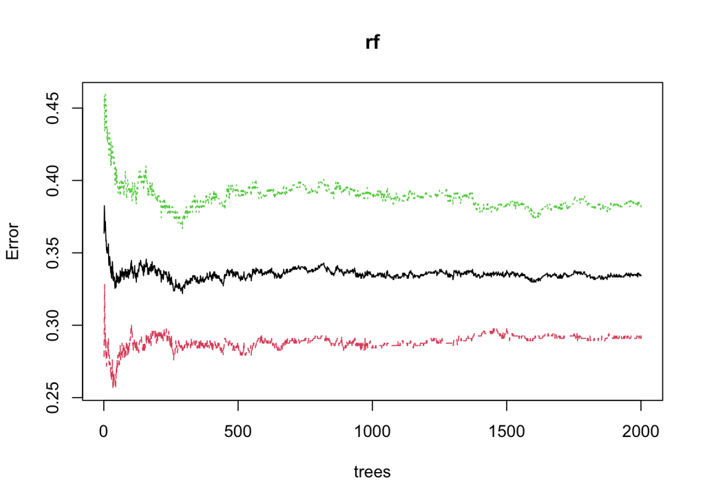

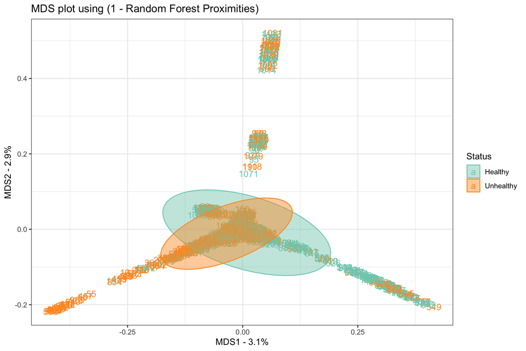

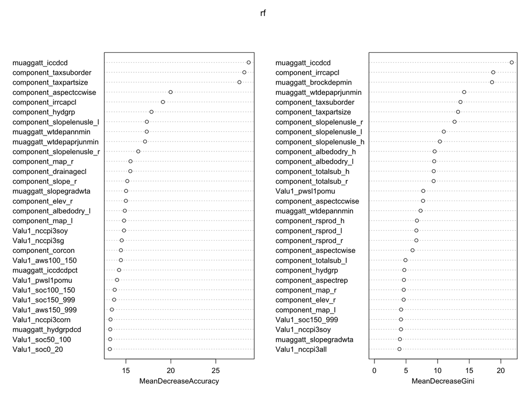

## Data visualization

```
##             Albolls   Andepts   Aqualfs   Aquands   Aquents   Aquepts    Aquods
##       136         1         1        27         9        21       184         1
##   Aquolls    Arents    Cryods  Fluvents    Humods   Humults  Ochrepts  Orthents
##        32        12         2        10         2         4        31        15
##   Orthods Psamments  Saprists  Tropepts    Udalfs    Udands    Udepts    Udults
##        58         8        20         1         6        11         9         1
##  Umbrepts  Vitrands   Xeralfs   Xerands   Xerepts   Xerolls
##       164         5        36        40       243        44
```

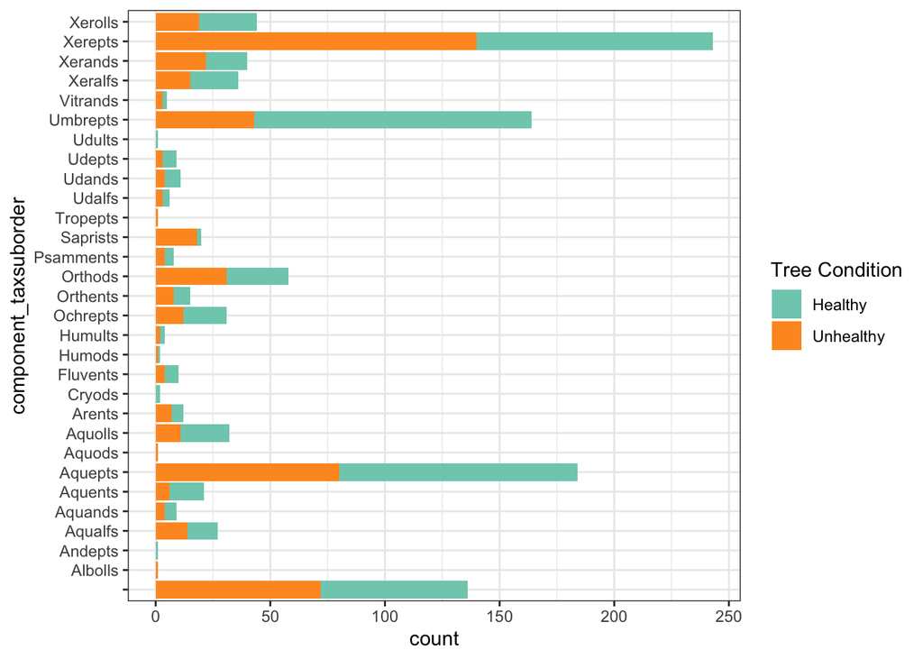

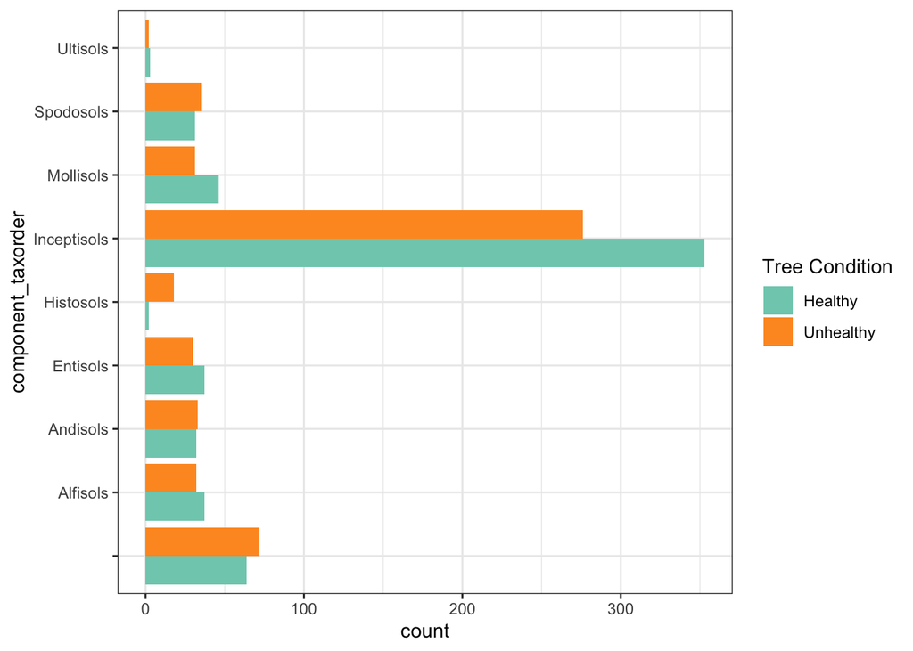

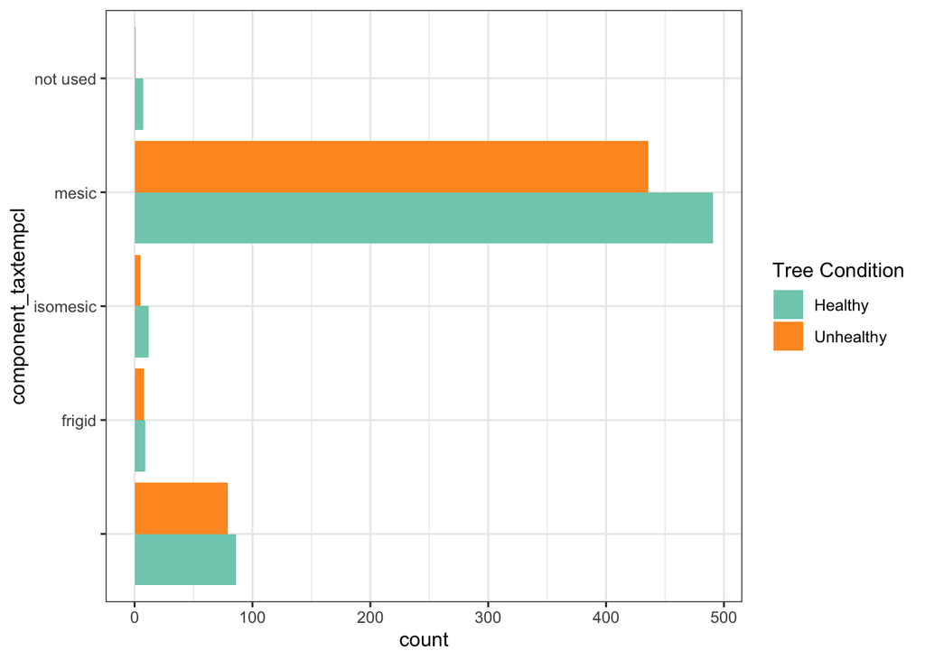

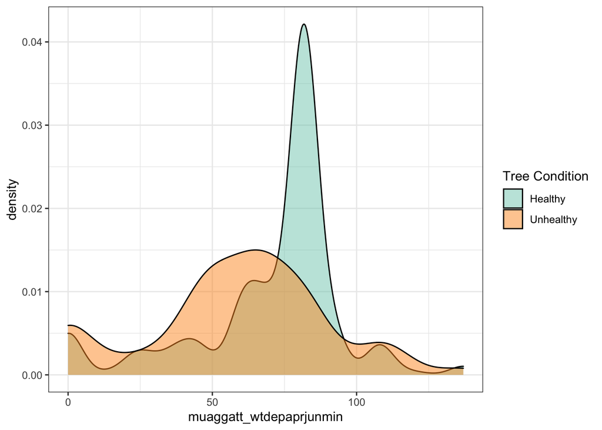

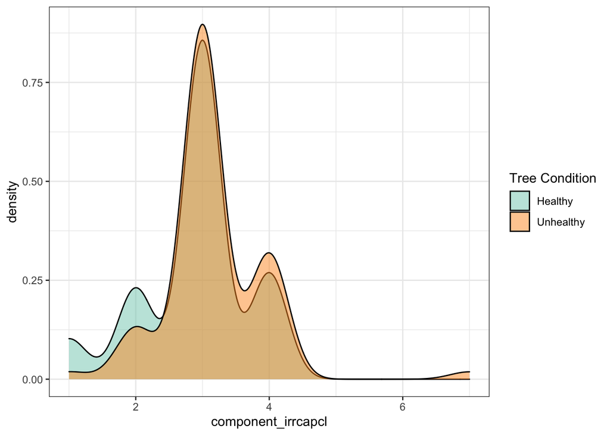

```
##
##                                       159
##                                      ashy
##                                        10
##                          ashy over clayey
##                                         4
##                           ashy over loamy
##                                         3
##                  ashy over loamy-skeletal
##                                         4
##         ashy over sandy or sandy-skeletal
##                                        12
##                             ashy-skeletal
##                                         4
##         ashy-skeletal over loamy-skeletal
##                                         1
##                                    clayey
##                                         2
##                              coarse-loamy
##                                        68
## coarse-loamy over sandy or sandy-skeletal
##                                        33
##                              coarse-silty
##                                         2
## coarse-silty over sandy or sandy-skeletal
##                                         1
##                                      fine
##                                        50
##                                fine-loamy
##                                        64
##   fine-loamy over sandy or sandy-skeletal
##                                        24
##                                fine-silty
##                                       164
##                                     loamy
##                                         5
##                            loamy-skeletal
##                                       214
##                                    medial
##                                       129
##                        medial over clayey
##                                         3
##                         medial over loamy
##                                         1
##       medial over sandy or sandy-skeletal
##                                         3
##                           medial-skeletal
##                                        29
##                                  not used
##                                        50
##                                     sandy
##                                         3
##                            sandy-skeletal
##                                        90
##                                 very-fine
##                                         2
```

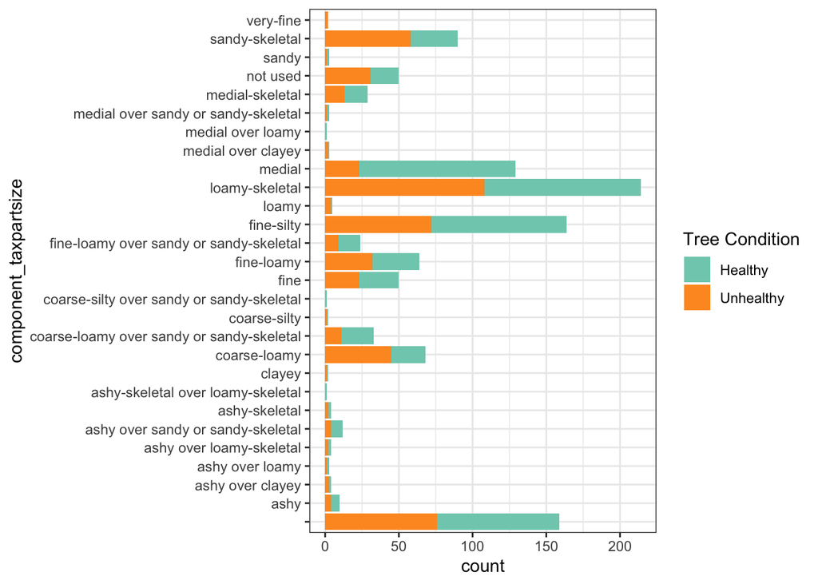

```
##    Min. 1st Qu.  Median    Mean 3rd Qu.    Max.    NA's
##   15.00   37.00   61.00   54.76   61.00  107.00     753
```

```
##    Min. 1st Qu.  Median    Mean 3rd Qu.    Max.    NA's
##   1.000   3.000   3.000   2.995   3.000   7.000     946
```

```
##    Min. 1st Qu.  Median    Mean 3rd Qu.    Max.    NA's
##       0    1000    1143    1246    1397    3429     141
```

```
##    Min. 1st Qu.  Median    Mean 3rd Qu.    Max.    NA's
##   1.000   2.000   3.000   2.861   3.000   7.000     954
```

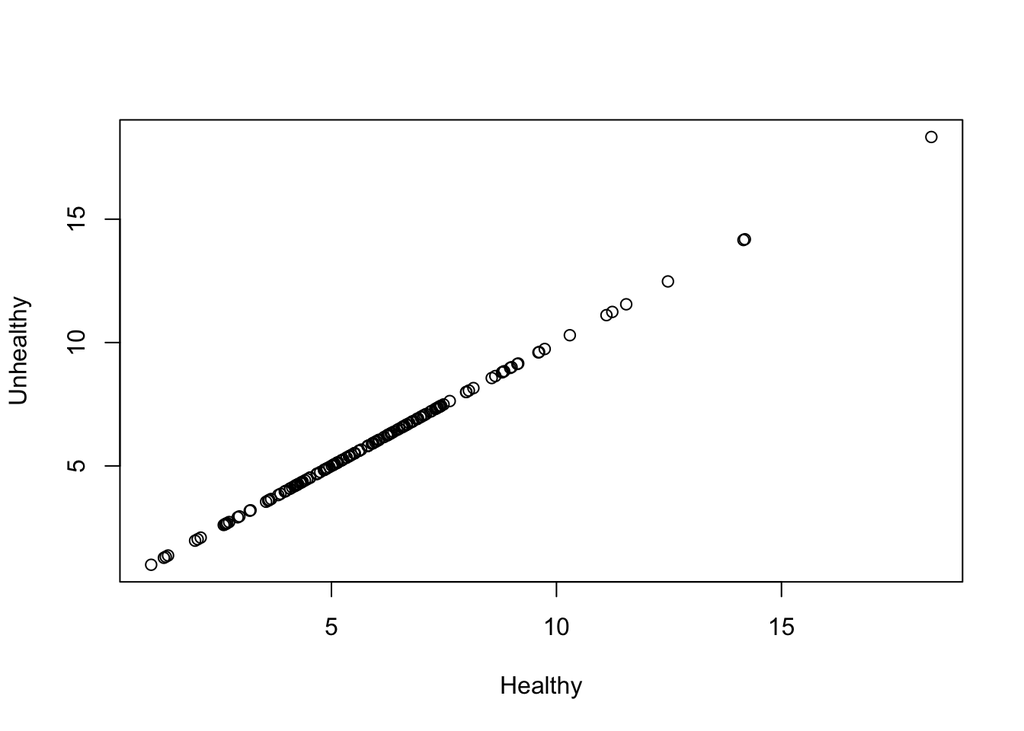